# R Notebook

# AUFGABE 17: ANOVA mit Messwiederholung, Einfaktorielle Varianzanalyse (mit Messwiederholung)

# Roadmap:

## 1. Hypothese

## 2. Voraussetzungen der einfaktoriellen Varianzanalyse mit Messwiederholung

## 3. Grundlegende Konzepte

## 4. Deskriptive Statistik

## 5. Mauchly-Test auf Sphärizität

## 6. Ergebnisse der einfaktoriellen Varianzanalyse mit Messwiederholung

## 7. Post-hoc-Tests

## 8. Profildiagramm

## 9. Berechnung der Effektstärke

## 10. Eine Aussage

# Beschreibung:

Es wurde eine Studie im Unternehmen “Effektivität und Effizienz” durchgeführt. Dazu wurden die Young Professionals zu Beginn des neuen Jobs, nach drei Monaten und nach 6 Monaten befragt, wie sich ihre Leistungsmotivation entwickelt hat. Wie verändert sich die Leistungsmotivation der neuen jungen und dynamtischen Mitarbeiter?

Daten Variable1: Phase Varibale2: Leistungsmovitation

```r
library(readxl)
mitmess <- read_excel("uebung17.xlsx")
mitmess
```

| ID | Phase | Leistungsmovitation |
| --- | --- | --- |
| 1 | Honeymoon(Anfang) | 45 |
| 2 | Honeymoon(Anfang) | 46 |
| 3 | Honeymoon(Anfang) | 43 |
| 4 | Honeymoon(Anfang) | 46 |
| 5 | Honeymoon(Anfang) | 46 |
| 6 | Honeymoon(Anfang) | 46 |
| 7 | Honeymoon(Anfang) | 46 |
| 8 | Honeymoon(Anfang) | 44 |
| 9 | Honeymoon(Anfang) | 48 |
| 10 | Honeymoon(Anfang) | 45 |

[output cut: 77 more lines]

```r
mitmess$Phase <- factor(mitmess$Phase, levels=c("Honeymoon(Anfang)", "Hangover(3M)", "Normalitaet(6M)" ))
```

```r
str(mitmess)
```

```
tibble [87 x 3] (S3: tbl_df/tbl/data.frame)
 $ ID                 : num [1:87] 1 2 3 4 5 6 7 8 9 10 ...
 $ Phase              : Factor w/ 3 levels "Honeymoon(Anfang)",..: 1 1 1 1 1 1 1 1 1 1 ...
 $ Leistungsmovitation: num [1:87] 45 46 43 46 46 46 46 44 48 45 ...
```

```r
View(mitmess)
```

```r
library(ggplot2)
library(dplyr)
library(psych)
library(car)
library(effsize)
library(lsr)
library(sjstats)
```

#1. Hypothese

H1: Die Leistungsmotivaton der Testpersonen unterscheidet sich zu verschiedenen Messzeitpunkten.

$$M_{anfang} \neq M_{3 Monat}\neq M_{6 Monat} \rightarrow \text{min. in einem Vergleich}$$

H0: Die Leistungsmotivation der Testpersonen unterscheidet sich nicht zu verschiedenen Messzeitpunkten.

$$M_{anfang} = M_{3 Monat}= M_{6 Monat}$$

#2. Voraussetzungen der einfaktoriellen Varianzanalyse mit Messwiederholung

Die abhängige Variable ist intervallskaliert -> Die Variable “Leistungsmotivation” ist metrisch (intervalskaliert).

Die abhängige Variable ist normalverteilt innerhalb jedes Messzeitpunktes (Ab > 25 Probanden pro Messzeitpunkt sind Verletzungen in der Regel unproblematisch) -> siehe Histogrammm oder QQ-Plot

Sphärizität ist gegeben -> siehe Mauchly-Test auf Sphärizität

### Normalverteilung der Daten mithilfe des Histogrammes

#### Alternativ 1

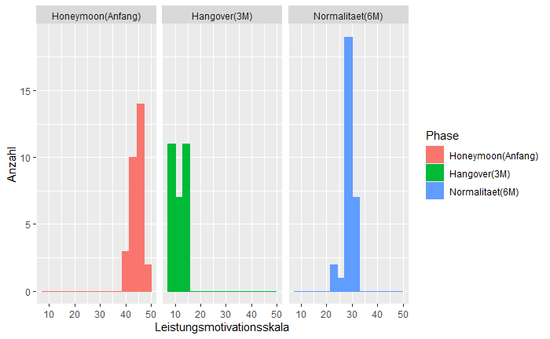

```r
library(car)
mitmess %>%
group_by(Phase) %>%
ggplot(aes(Leistungsmovitation, color=Phase)) +
geom_histogram(aes(fill = Phase), bins = 15) +
facet_wrap(~Phase) +
theme_grey()+
labs(x= "Leistungsmotivationsskala",y = "Anzahl" )
```

#### Alternativ 2

```
[1] 31  9
```

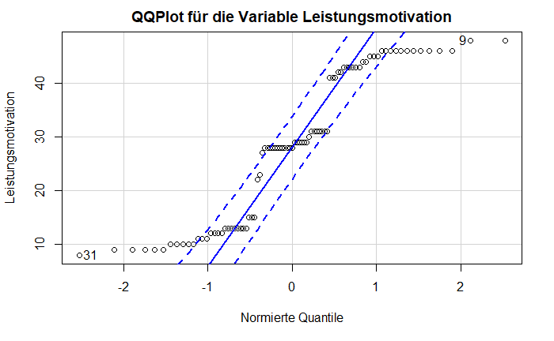

```r
qqPlot(mitmess$Leistungsmovitation,
main = "QQPlot für die Variable Leistungsmotivation",
xlab = "Normierte Quantile",
ylab = "Leistungsmotivation"
)
```

Die Daten sind augenscheinlich eher nicht normalverteilt. Daher sollte der Friedman bevorzugt werden. Allerdings im Rahmen der Übungen und unter Anbetracht der Größe der Daten wir die Normalverteilung als gegeben angesehen.

#### Alternativ 3

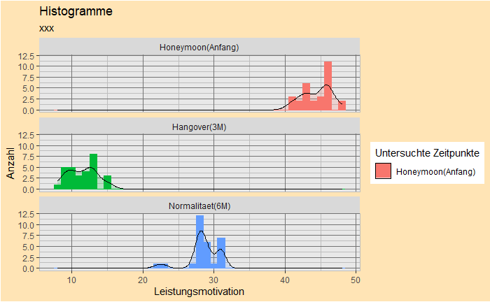

```r
ggplot(mitmess,
aes(Leistungsmovitation,
color=Phase
)
) +
geom_histogram(binwidth=1,
aes(fill = Phase),
bins = 6,
show.legend = TRUE
) +
geom_density(aes(y = ..count..,
fill = Phase
),
alpha=0.2,
colour = "black",
size = 0.3,
show.legend = TRUE
) +
theme(panel.background = element_rect(size = 0.5, fill = "gray91", colour = "gray", linetype='solid'),
panel.grid.major = element_line(size = 0.5, linetype = 'solid', colour = "gray45"),
panel.grid.minor = element_line(size = 0.5, linetype = 'solid', colour = "gray"),
plot.background = element_rect(fill = "moccasin")
)+
scale_fill_discrete(name = "Untersuchte Zeitpunkte",
breaks = c("Honeymoon(Anfang)", "   Hangover(3M)", "    Normalitaet(6M)"),
labels = c("Honeymoon(Anfang)",
"   Hangover(3M)",
"   Normalitaet(6M)"
),
aesthetics = "fill" # Die System-Farben werden verwendet.
)+
guides(#fill = FALSE, # Mit "fill = FALSE" werden alle Legenden (automatisch,manuell) abgeschaltet.
color = FALSE
) +
facet_wrap(~ Phase,
ncol = 1
) +
labs(title = "Histogramme",
subtitle = "xxx",
x = "Leistungsmotivation",
y = "Anzahl"
)
```

#3. Grundlegende Konzepte

Die Fragestellung der einfaktoriellen Varianzanalyse mit Messwiederholung wird oft so verkürzt: “Unterscheiden sich die Mittelwerte einer abhängigen Variable zwischen mehreren abhängigen Gruppen, resp. Messzeitpunkten?”

#4. Deskriptive Statistik

```r
mitmess %>%
group_by(mitmess$Phase) %>%
summarize(Anzahl = n(), Mittelwert = mean(Leistungsmovitation), Median = median(Leistungsmovitation), Standardabweichung = sd(Leistungsmovitation)) %>%
mutate_if(is.numeric, round, 2)
```

| mitmess$Phase | Anzahl | Mittelwert | Median | Standardabweichung |
| --- | --- | --- | --- | --- |
| Honeymoon(Anfang) | 29 | 44.48 | 45 | 2.01 |
| Hangover(3M) | 29 | 11.48 | 12 | 1.99 |
| Normalitaet(6M) | 29 | 28.59 | 28 | 2.11 |

#5. Mauchly-Test auf Sphärizität

H0 :Die Varianzen der Differenzen zwischen jeweils zwei Messzeitpunkten sind gleich. (Sphärizität) H1 :Die Varianzen der Differenzen zwischen jeweils zwei Messzeitpunkten sind nicht gleich.(keine Sphärizität)

Ist das Epsilon: p > 0.05 => Ergebnis nicht Signifikant –> Sphärizität Ist das Epsilon: p < 0.05 => Ergebnis Signifikant –> keine Sphärizität-> Wenn dies der Fall ist, müssen die Freiheitsgrade mit dem Korrekturfaktor angepasst werden.

-> Ist Epsilon < 0.75 ->Greenhouse-Geisser -> Ist Epsilon > 0.75 ->Huynh-Feldt

#6. Ergebnisse der einfaktoriellen Varianzanalyse mit Messwiederholung

```r
library(afex)

anova <- aov_car(Leistungsmovitation~Error(ID/Phase), data =mitmess, return ="univariate")
anova
```

```
Univariate Type III Repeated-Measures ANOVA Assuming Sphericity

            Sum Sq num Df Error SS den Df F value    Pr(>F)
(Intercept)  69107      1   147.06     28 13158.1 < 2.2e-16 ***
Phase        15798      2   202.46     56  2184.8 < 2.2e-16 ***
---
Signif. codes:  0 ‘***’ 0.001 ‘**’ 0.01 ‘*’ 0.05 ‘.’ 0.1 ‘ ’ 1


Mauchly Tests for Sphericity

      Test statistic p-value
Phase        0.91916 0.32048


Greenhouse-Geisser and Huynh-Feldt Corrections
 for Departure from Sphericity

       GG eps Pr(>F[GG])
Phase 0.92521  < 2.2e-16 ***
---
Signif. codes:  0 ‘***’ 0.001 ‘**’ 0.01 ‘*’ 0.05 ‘.’ 0.1 ‘ ’ 1

         HF eps   Pr(>F[HF])
Phase 0.9878193 3.080941e-53
```

p = 0.32 > 0.05 => Ergebnis nicht Signifikant –> Sphärizität und keine Anpassung.

```r
out5b <- aov_car(Leistungsmovitation~Error(ID/Phase), data = mitmess)
out6a <- anova(out5b, es="pes", correction="none", intercept= TRUE)
out6b <- anova(out5b, es="pes", correction="GG")
out6c <- anova(out5b, es="pes", correction="HF")
out6 <- rbind("nicht Korrigiert"=out6a, "Greenhouse-Geisser"=out6b, "Huynh-Feldt"=out6c)
out6
```

```
Anova Table (Type 3 tests)

Response: Leistungsmovitation
                             num Df den Df    MSE       F     pes    Pr(>F)
nicht Korrigiert.(Intercept) 1.0000 28.000 5.2521 13158.1 0.99788 < 2.2e-16 ***
nicht Korrigiert.Phase       2.0000 56.000 3.6154  2184.8 0.98735 < 2.2e-16 ***
Greenhouse-Geisser           1.8504 51.812 3.9076  2184.8 0.98735 < 2.2e-16 ***
Huynh-Feldt                  1.9756 55.318 3.6599  2184.8 0.98735 < 2.2e-16 ***
---
Signif. codes:  0 ‘***’ 0.001 ‘**’ 0.01 ‘*’ 0.05 ‘.’ 0.1 ‘ ’ 1
```

In diesem Beispiel wird keine Korrektur durchgeführt, daher werden wir df1 = 2 und df2 = 56.

Eine Varianzanalyse mit Messwiederholung zeigt, dass sich die Leistungsmovitation der ProbandInnen je nach Messzeitpunkt unterscheidet. (F(2, 56) = 2184.8, p = .000, n = 29).

#7. Post-hoc-Tests

$$\frac{k*(k-1)}{2}=\frac{3*(3-1)}{2}= \frac{6}{2} =3$$

Hierbei wird α durch die Anzahl der Paarvergleiche dividiert. Im hier aufgeführten Fall ist dies .05/3 = .016

```r
pairwise.t.test(mitmess$Leistungsmovitation,
mitmess$Phase,
p.adjust.method = "none",
paired = TRUE,
data = mitmess)
```

```
    Pairwise comparisons using paired t tests

data:  mitmess$Leistungsmovitation and mitmess$Phase

                Honeymoon(Anfang) Hangover(3M)
Hangover(3M)    <2e-16            -
Normalitaet(6M) <2e-16            <2e-16

P value adjustment method: none
```

```r
sprintf("adjusted p value: %f", (0.05/3))
```

```
[1] "adjusted p value: 0.016667"
```

Es wird ersichtlich, dass alle drei Messzeitpunkt sich sig unterscheiden (p < .016). Daher lassen sich für eigenständige Gruppen bilden. Diese drei Gruppen sind generalisierbar.

#8. Profildiagramm

```
`fun.y` is deprecated. Use `fun` instead.`fun.y` is deprecated. Use `fun` instead.
```

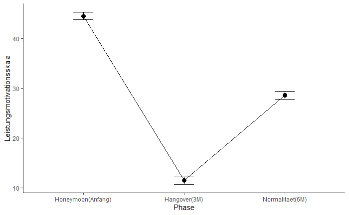

```r
ggplot(mitmess, aes(x=Phase, y=Leistungsmovitation, group=1))+
stat_summary(fun.y = mean, geom="point", size=3)+
stat_summary(fun.y = mean, geom="line")+
stat_summary(fun.data = mean_cl_normal, geom="errorbar", width=.2, size=.25)+
labs(x="Phase", y="Leistungsmotivationsskala")+
theme_classic()
```

Es zeigt sich, dass die Leistungsmotivation der ProbandInnen zum Messzeitpunkt Honeymoon (M =44.48, SD = 2.01, n=29) signifikant höher sind als zum Messzeitpunkt Hangover (3M) (M =11.48, SD = 1.99, n=29) aber wieder zum Messzeitpunkt Normalität(6M)(M =28.59, SD=2.11, n=29) steigt.

# Das partielle Eta-Quadrat

Das partielle Eta-Quadrat (partielles η2) ist ein Mass für die Effektgrösse: Es setzt die Varianz, die durch einen Faktor erklärt wird, in Bezug mit jener interessierenden Varianz, die noch nicht durch andere Faktoren im Modell erklärt wird. Das heisst, es wird ausschliesslich jene Variation betrachtet, welche im Fokus des Interesses steht und nicht bereits durch die anderen Faktoren im Modell erklärt wird. Das partielle Eta-Quadrat zeigt, welchen Anteil davon ein Faktor erklärt. Im Falle der einfaktoriellen Varianzanalyse mit Messwiederholung liegt das Interesse ausschliesslich auf der Varianz innerhalb der Personen (SSinnerhalb Personen = SSTreatment + SSResidual), weswegen sich das partielle Eta-Quadrat wie folgt berechnet

$$eta_p^2 = \frac{SS_{Treatment}}{SS_{Treatment}+SS_{Residual}}$$

```r
sprintf("Partielle Eta-Quadrat für 'Phase': eta= %.4f", out6a$pes[2])
```

```
[1] "Partielle Eta-Quadrat für 'Phase': eta= 0.9873"
```

Im vorliegenden Beispiel beträgt das partielle Eta-Quadrat .9873. Das heisst, es wird 98,73% der Variation der Leistungsmotivation durch die Messzeiten aufgeklärt.

#9. Berechnung der Effektstärke

```r
effneu <- sqrt(out6a$pes[2]/(1-out6a$pes[2]))

sprintf("Effektstärke: f= %.3f",effneu)
```

```
[1] "Effektstärke: f= 8.833"
```

Um zu beurteilen, wie gross dieser Effekt ist, kann man sich an der Einteilung von Cohen (1988) orientieren:

$$\begin{align}
\text{Schwacher Effekt: } 0.10 &< ||f|| < 0.25 \\
\text{Schwacher bis mittlerer Effekt: } 0.25 &= ||f|| \\
\text{Mittlerer Effekt: } 0.25 &< ||f|| < 0.40 \\
\text{Mittlerer bis starker Effekt: }0.40 &= ||f|| \\
\text{Starker Effekt: } 0.40 &< ||f||
\end{align}$$

Damit entsprechen die Effektstärken von 8.833 einem starken Effekt.

#10. Eine Aussage

Eine Varianzanalyse mit Messwiederholung zeigt, dass sich die Leistungsmotivation der ProbandInnen je nach Messzeitpunkt unterscheidet. (F(2,56) = 2184.8, p < .000, partielles η2 = .9873, n = 29). Der Mauchly-Test ergab, dass Sphärizität gegeben ist (p=0.32) (p>0.05), weshalb die Greenhouse-Geisser-Korrektur nicht angewendet wurde, wodurch sich korrigierte Freiheitsgrade nicht ergeben.

Der Post-Hoc-Test zeigt, dass die Leistungsmotivation der ProbandInnen zum Messzeitpunkt Honeymoon (M =44.48, SD = 2.01, n=29) signifikant höher sind als zum Messzeitpunkt Hangover (3M) (M =11.48, SD = 1.99, n=29) aber wieder zum Messzeitpunkt Normalität(6M)(M =28.59, SD=2.11, n=29) steigt .

Die Effektstärke liegt bei f=8.833 und entspricht damit nach Cohen (1988) einem starken Effekt. H0 kann verworfen werden, H1 angenommen.